# Curve Fitting in Python: Logarithmic Functions

⇦ Back

If you have a set of data points that look like they initially increase rapidly before tailing off, it might be useful to fit them with a smooth, logarithmically increasing line in order to describe their general shape:

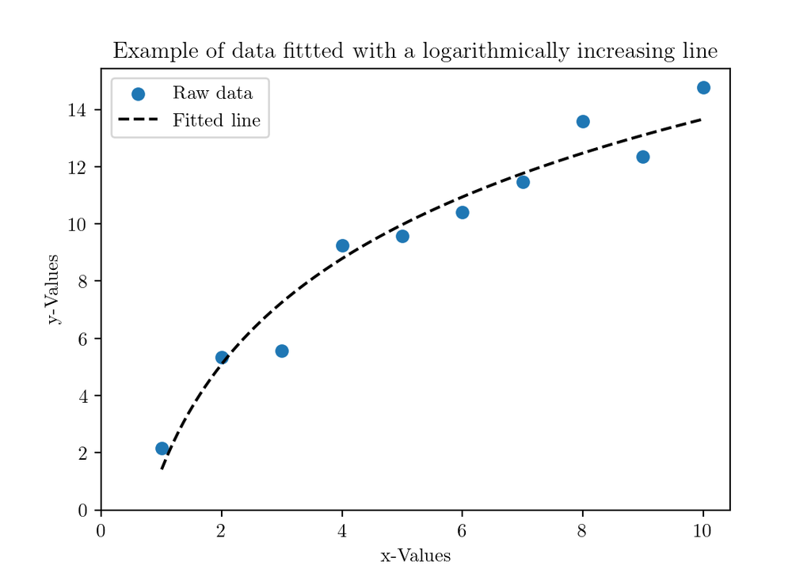

The line that you need to fit in order to achieve this shape will be one that is described by a logarithmic function, that is any function of the form:

$y = a \times\ln\left(x - c\right) + b$

where $\ln$ is the natural logarithm ($\log_e$). The important thing to realise is that *a logarithmic function can be fully defined with three constants*. The above formulation of a logarithmic function can be written in Python as `a * np.log(x - c) + b` where `log()` is the natural logarithm function as provided by the Numpy package (renamed `np` in our examples).

# Example Data

For this tutorial, let’s create some fake data to use as an example. This should be a set of points that increase logarithmically (or else our attempts to fit a logarithmic curve to them won’t work well!) with some random noise thrown in to mimic real-world data:

```python
import numpy as np

# Set a seed for the random number generator so we get the same random numbers
# each time we run the code
np.random.seed(20210714)

# Create fake x-data
x = np.arange(1, 11)
# Create fake y-data
a = 5
b = 2
c = 0.3
y = a * np.log(x - c) + b
y = y + np.random.normal(scale=0.05 * max(y), size=len(x))  # Add noise
```

The random noise is being added with the `random.normal()` function from Numpy which draws random samples from a normal (Gaussian) distribution. Let’s take a look at what this example data looks like on a scatter plot:

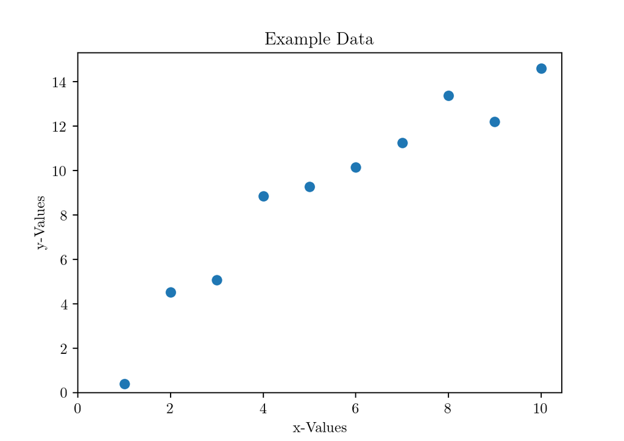

```python
import matplotlib.pyplot as plt

# Formatting options for plots
A = 6  # Want figure to be A6
plt.rc('figure', figsize=[46.82 * .5**(.5 * A), 33.11 * .5**(.5 * A)])
plt.rc('text', usetex=True)
plt.rc('font', family='serif')
plt.rc('text.latex', preamble=r'\usepackage{textgreek}')

# Create a plot
ax = plt.axes()
ax.scatter(x, y)
ax.set_title('Example Data')
ax.set_ylabel('y-Values')
ax.set_xlabel('x-Values')
ax.set_ylim(0)
ax.set_xlim(0)
plt.show()
```

# Method 1: polyfit

> This method only works when $c = 0$, ie when you want to fit a curve with equation $y = a \times\ln\left(x\right) + b$ to your data. If you want to fit a curve with equation $y = a \times\ln\left(x - c\right) + b$ with $c \neq 0$ you will need to use method 2.

The `polyfit()` command from Numpy is used to fit a polynomial function to data. This might seem a little strange: why are we trying to fit a *polynomial function* to the data when we want to fit a *logarithmic function*? The answer is that we can convert a logarithmic function into a polynomial one by using the fact that $y = a \times\ln\left(x\right) + b$ is linear in $\ln(x)$. In other words, we can create a linear equation $f(t) = mt + c$ where:

- $f(t) = y$
- $t = \ln(x)$
- $m = a$
- $c = b$

So `polyfit()` can be used to fit $y$ against $\ln(x)$ with a polynomial of degree 1 (aka a linear curve):

```python
import numpy as np

# Set a seed for the random number generator so we get the same random numbers
# each time we run the code
np.random.seed(20210714)

# Create fake x-data
x = np.arange(1, 11)
# Create fake y-data
a = 5
b = 2
y = a * np.log(x) + b
y = y + np.random.normal(scale=0.05 * max(y), size=len(x))  # Add noise

# Fit a polynomial of degree 1 (a linear function) to the data
t = np.log(x)
p = np.polyfit(t, y, 1)
```

The parameter coefficients can now be extracted and used to create the fitted curve:

```python
# Construct the fitted curve
a = p[0]
b = p[1]
x_fitted = np.linspace(np.min(x), np.max(x), 100)
y_fitted = a * np.log(x_fitted) + b
```

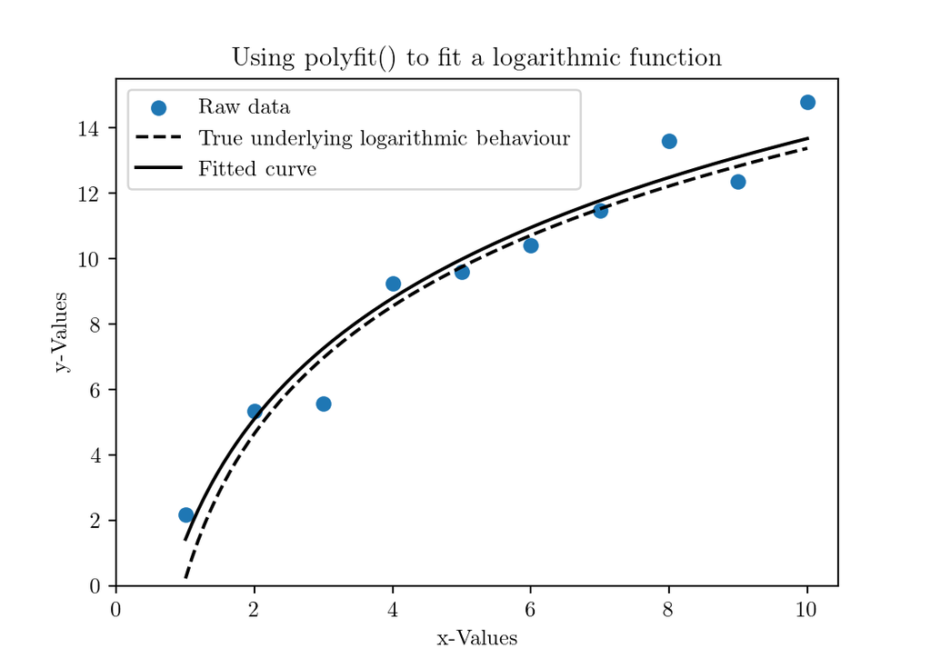

```python
import matplotlib.pyplot as plt

# True underlying logarithmic behaviour
x_true = np.linspace(np.min(x), np.max(x), 100)
y_true = 5 * np.log(x_true - 0.3) + 2

# Plot
ax = plt.axes()
ax.scatter(x, y, label='Raw data')
ax.plot(x_true, y_true, 'k--', label='True underlying logarithmic behaviour')
ax.plot(x_fitted, y_fitted, 'k', label='Fitted curve')
ax.set_title('Using polyfit() to fit a logarithmic function')
ax.set_ylabel('y-Values')
ax.set_xlabel('x-Values')
ax.set_ylim(0)
ax.set_xlim(0)
ax.legend()
plt.show()
```

# Method 2: curve_fit

From the Scipy pacakge we can get the `curve_fit()` function. This is more general than `polyfit()` - we can fit *any* type of function we like, not just polynomials - but it’s more complicated in that we sometimes need to provide an initial guess as to what the constants could be in order for it to work.

Let’s use our original example data (ie with $c \neq 0$):

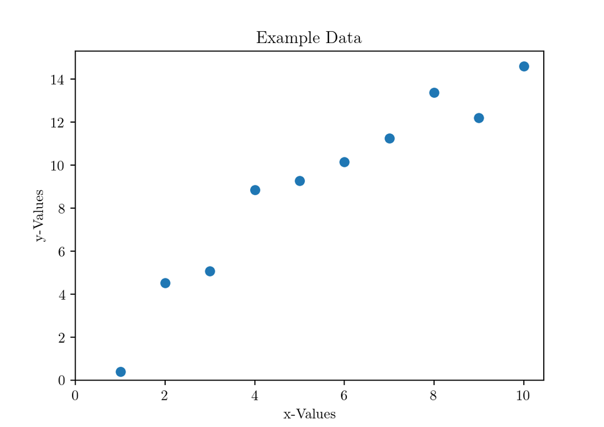

```python
import numpy as np
import matplotlib.pyplot as plt

# Set a seed for the random number generator so we get the same random numbers
# each time we run the code
np.random.seed(20210714)

# Create fake x-data
x = np.arange(1, 11)
# Create fake y-data
a = 5
b = 2
c = 0.3
y = a * np.log(x - c) + b
y = y + np.random.normal(scale=0.05 * max(y), size=len(x))  # Add noise

# Create a plot
ax = plt.axes()
ax.scatter(x, y)
ax.set_title('Example Data')
ax.set_ylabel('y-Values')
ax.set_xlabel('x-Values')
ax.set_ylim(0)
ax.set_xlim(0)
plt.show()
```

Now let’s fit the function $y = a \times\ln\left(x - c\right) + b$. This is done by defining it as a **lambda function** (ie as an *object* rather than as a command) of a dummy variable $t$ and using the `curve_fit()` function to fit this object to the x- and y-data. Note that the `curve_fit()` function needs to be imported from the `scipy.optimize` sub-package:

```python
from scipy.optimize import curve_fit

# Fit the function a * np.log(t - c) + b to x and y
popt, pcov = curve_fit(lambda t, a, b, c: a * np.log(t - c) + b, x, y)
```

The first output, `popt`, is a list of the **opt**imised values for the **p**arameters which, in our case, are the constants $a$, $b$ and $c$:

```python
a = popt[0]
b = popt[1]
c = popt[2]
```

Let’s see what this looks like:

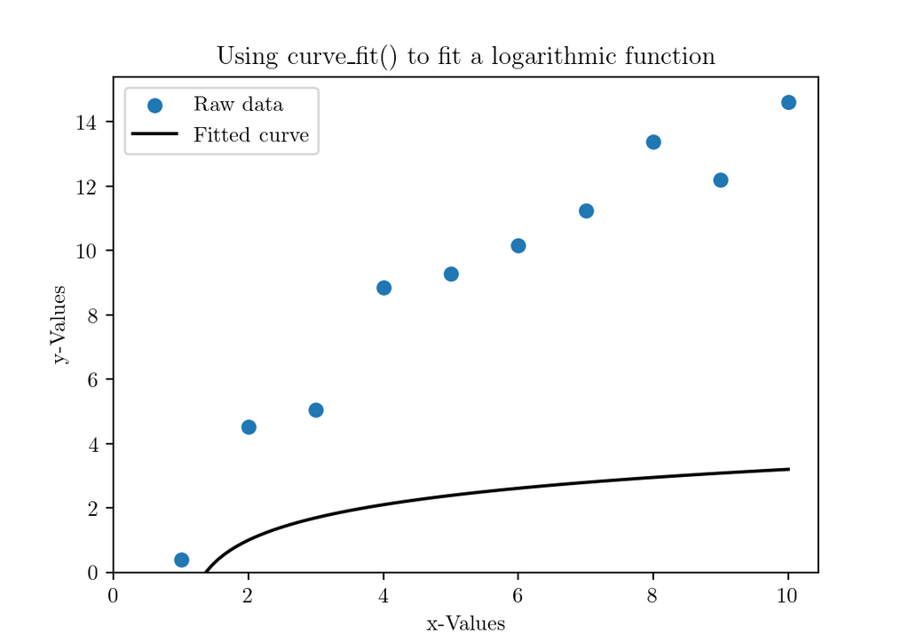

```python
# Create the fitted curve
x_fitted = np.linspace(np.min(x), np.max(x), 100)
y_fitted = a * np.log(x_fitted - c) + b

# Plot
ax = plt.axes()
ax.scatter(x, y, label='Raw data')
ax.plot(x_fitted, y_fitted, 'k', label='Fitted curve')
ax.set_title(r'Using curve\_fit() to fit a logarithmic function')
ax.set_ylabel('y-Values')
ax.set_xlabel('x-Values')
ax.set_ylim(0)
ax.set_xlim(0)
ax.legend()
plt.show()
```

That’s a terrible fit! The reason it’s gone wrong is because the optimisation algorithm behind `curve_fit()` got overwhelmed by having to guess-and-optimise three constants at the same time and so probably chose the wrong local minima somewhere. The way to help it along is by providing it with an **initial guess** `p0` of what the parameters are in order to give it an idea of what numbers to look at:

```python
# Have an initial guess as to what the values of the parameters are
# (we happen to know that the exact values of the constants are a = 5, b = 2 and
# c = 0.3, but let's make our guess a = 6, b = 1.5, c = 0.2 in order to give the
# algorithm something to do)
a_guess = 6
b_guess = 1.5
c_guess = 0.2

# Fit the function a * np.log(t - c) + b to x and y
popt, pcov = curve_fit(
    lambda t, a, b, c: a * np.log(t - c) + b, x, y,
    p0=(a_guess, b_guess, c_guess)
)

# The optimised values of the parameters are
a = popt[0]
b = popt[1]
c = popt[2]

print(a, b, c)
```

```
## 7.487886585111866 -3.7964564085588193 -0.78076614295256
```

These aren’t particularly close to the true values of the constants, but the fitted curve they create is pretty good nonetheless:

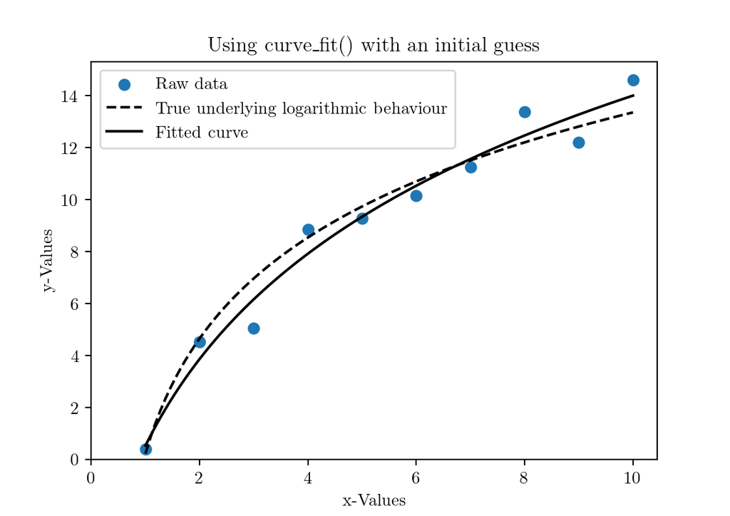

```python
# True underlying logarithmic behaviour
x_true = np.linspace(np.min(x), np.max(x), 100)
y_true = 5 * np.log(x_true - 0.3) + 2

# Create the fitted curve
x_fitted = np.linspace(np.min(x), np.max(x), 100)
y_fitted = a * np.log(x_fitted - c) + b

# Plot
ax = plt.axes()
ax.scatter(x, y, label='Raw data')
ax.plot(x_true, y_true, 'k--', label='True underlying logarithmic behaviour')
ax.plot(x_fitted, y_fitted, 'k', label='Fitted curve')
ax.set_title(r'Using curve\_fit() with an initial guess')
ax.set_ylabel('y-Values')
ax.set_xlabel('x-Values')
ax.set_ylim(0)
ax.set_xlim(0)
ax.legend()
plt.show()
```

An initial guess has improved the result considerably!

# Interpolation and Extrapolation (Forecasting/Predicting/Estimating)

We can use the fitted curve to estimate what our data would be for other values of $x$ that are not in our raw dataset: what would the value be at $x=12$ (which is outside of our domain and thus requires us to forecast into the future) or $x = 8.5$ (which is inside of our domain and thus requires us to ‘fill in a gap’ in our data)? To answer these questions, we simply plug these x-values as numbers into the equation of the fitted curve:

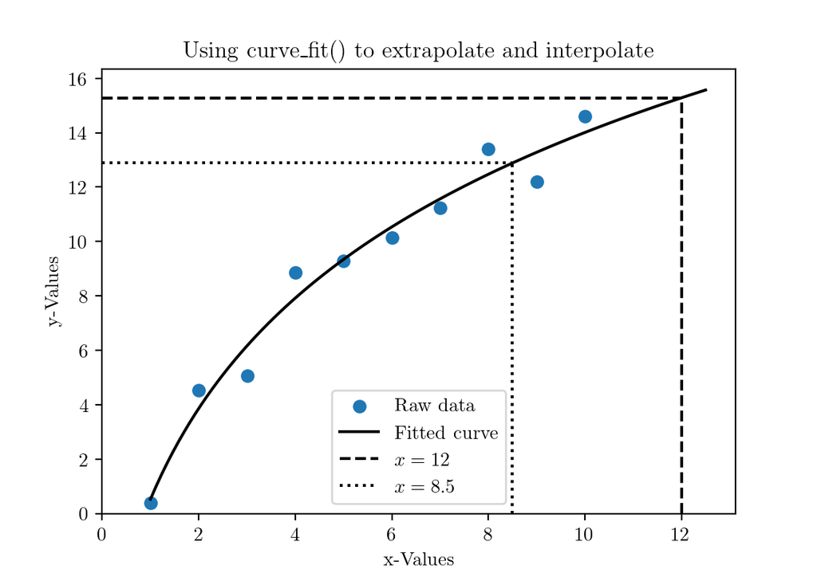

```python
# Provide an initial guess
a_guess = 6
b_guess = 1.5
c_guess = 0.2
# Fit the function a * np.log(t - c) + b to x and y
popt, pcov = curve_fit(
    lambda t, a, b, c: a * np.log(t - c) + b, x, y,
    p0=(a_guess, b_guess, c_guess)
)
# Extract the optimised parameters
a = popt[0]
b = popt[1]
c = popt[2]
# Create the model function
x_fitted = np.linspace(np.min(x), 12.5, 100)
y_fitted = a * np.log(x_fitted - c) + b

# Extrapolation
y_12 = a * np.log(12 - c) + b

# Interpolation
y_8_5 = a * np.log(8.5 - c) + b

#
# Plot
#
ax = plt.axes()
ax.scatter(x, y, label='Raw data')
ax.plot(x_fitted, y_fitted, 'k', label=r'Fitted curve')
# Add result of extrapolation
ax.plot([12, 12], [0, y_12], 'k--', label=r'$x=12$')
ax.plot([0, 12], [y_12, y_12], 'k--')
# Add result of interpolation
ax.plot([8.5, 8.5], [0, y_8_5], 'k:', label=r'$x=8.5$')
ax.plot([0, 8.5], [y_8_5, y_8_5], 'k:')
ax.set_title(r'Using curve\_fit() to extrapolate and interpolate')
ax.set_ylabel('y-Values')
ax.set_xlabel('x-Values')
ax.set_ylim(0)
ax.set_xlim(0)
ax.legend()
plt.show()
```

More explicitly:

```python
print(f'x = 12 implies y = {y_12:5.2f}; x = 8.5 implies y = {y_8_5:5.2f}')
```

```
## x = 12 implies y = 15.28; x = 8.5 implies y = 12.89
```

# Using a Bar Plot

If you want to use a bar plot instead of a scatter plot:

[figure not shown]

```python
# Provide an initial guess
a_guess = 6
b_guess = 1.5
c_guess = 0.2
# Fit the function a * np.log(t - c) + b to x and y
popt, pcov = curve_fit(
    lambda t, a, b, c: a * np.log(t - c) + b, x, y,
    p0=(a_guess, b_guess, c_guess)
)
# Extract the optimised parameters
a = popt[0]
b = popt[1]
c = popt[2]
# Create the model function
x_fitted = np.linspace(np.min(x), 10, 100)
y_fitted = a * np.log(x_fitted - c) + b

# Plot
ax = plt.axes()
ax.bar(x, y, label='Raw data')
ax.plot(x_fitted, y_fitted, 'k', label='Fitted curve')
ax.set_xticks(x)
ax.set_xticklabels([
    'One', 'Two', 'Three', 'Four', 'Five',
    'Six', 'Seven', 'Eight', 'Nine', 'Ten'
])
ax.set_xlim([1.5, len(y) + 0.5])
ax.tick_params(axis='x', length=0, labelsize=6)
xlocs = np.arange(len(y) + 1) + 0.5
ax.set_xticks(xlocs, minor=True)
ax.set_title(r'Using curve\_fit() to fit a logarithmic function')
ax.set_ylabel('y-Values')
ax.set_xlabel('x-Values')
ax.legend()
plt.show()
```

⇦ Back